# COMPASS - Combinatorial Polyfunctionality Analysis of Single Cells

## Introduction

Rapid advances in flow cytometry and other single-cell technologies have enabled high-dimensional, multi-parameter, high-throughput measurements of individual cells. Numerous questions about cell population heterogeneity can now be addressed, as these novel technologies permit single-cell analysis of antigen-specific T-cells. Unfortunately, there is a lack of computational tools to take full advantage of these complex data. COMPASS is a statistical framework that enables unbiased analysis of antigen-specific T-cell subsets. COMPASS uses a Bayesian hierarchical framework to model all observed cell-subsets and select the most likely to be antigen-specific while regularizing the small cell counts that often arise in multi-parameter space. The model provides a posterior probability of specificity for each cell subset and each sample, which can be used to profile a subject’s immune response to external stimuli such as infection or vaccination.

## Example

We will use a simulated dataset to illustrate the use of the `COMPASS` package.

First, we will outline the components used to construct the `COMPASSContainer`, the data structure used to hold data from an ICS experiment. We will first initialize some parameters used in generating the simulated data.

```r
library(COMPASS)
set.seed(123)
n <- 100  ## number of samples
k <- 6  ## number of markers

sid_vec <- paste0("sid_", 1:n)  ## sample ids; unique names used to denote samples
iid_vec <- rep_len(paste0("iid_", 1:(n/10)), n)  ## individual ids
```

The `COMPASSContainer` is built out of three main components: the **data**, the total **counts**, and the **metadata**. We will describe the R structure of these components next.

### data

This is a list of matrices, with each matrix representing a population of cells drawn from a particular sample. Each row is an individual cell, each column is a marker (cytokine), and each matrix element is an intensity measure associated with a particular cell and marker. Only cells that express at least one marker are included.

```r
data <- replicate(n, {
    nrow <- round(runif(1) * 10000 + 1000)
    ncol <- k
    vals <- rexp(nrow * ncol, runif(1, 1e-05, 0.001))
    vals[vals < 2000] <- 0
    output <- matrix(vals, nrow, ncol)
    output <- output[apply(output, 1, sum) > 0, ]
    colnames(output) <- paste0("M", 1:k)
    return(output)
})
names(data) <- sid_vec
head(data[[1]])
```

```
##        M1   M2   M3   M4   M5   M6
## [1,]    0 2990    0 2121    0 3119
## [2,]    0 2631    0 3423 3559    0
## [3,]    0 2970    0 3521    0 3351
## [4,]    0    0 3004    0    0    0
## [5,]    0    0 2365    0 5174 3716
## [6,] 3449    0    0    0    0    0
```

### counts

This is a named integer vector, denoting the total number of cells that were recovered from each sample in `data`.

```r
counts <- sapply(data, nrow) + round(rnorm(n, 10000, 1000))
counts <- setNames(as.integer(counts), names(counts))
head(counts)
```

```
## sid_1 sid_2 sid_3 sid_4 sid_5 sid_6
## 12911 15610 17694 17256 11453 12499
```

### metadata

This is a `data.frame` that associates metadata information with each sample available in `data` / `counts`. We will suppose that each sample was subject to one of two treatments named `Control` and `Treatment`.

```r
meta <- data.frame(sid = sid_vec, iid = iid_vec, trt = sample(c("Control", "Treatment"),
    n, TRUE))
head(meta)
```

```
##     sid   iid       trt
## 1 sid_1 iid_1 Treatment
## 2 sid_2 iid_2   Control
## 3 sid_3 iid_3 Treatment
## 4 sid_4 iid_4   Control
## 5 sid_5 iid_5   Control
## 6 sid_6 iid_6   Control
```

Once we have these components, we can construct the `COMPASSContainer`:

```r
CC <- COMPASSContainer(
  data=data,
  counts=counts,
  meta=meta,
  individual_id="iid", ## name of individual id vector in metadata
  sample_id="sid", ## name of sample id vector in metadata
  stimulation_id="trt" ## what treatment was applied to each sample?
)
```

We can see some basic information about our `COMPASSContainer`:

```r
CC
```

```
## An object of class COMPASSContainer with 100 samples and 6 markers.
```

```r
summary(CC)
```

```
## An object of class COMPASSContainer with 100 samples and 6 markers.
## The metadata describes 3 variables on 100 samples. The columns are:
##
##  sid iid trt
```

[figure not shown]

Fitting the `COMPASS` model is very easy once the data has been inserted into the `COMPASSContainer` object. To specify the model, the user needs to specify the criteria that identify samples that received a positive stimulation, and samples that received a negative stimulation. In our data, we can specify it as follows. (Because MCMC is used to sample the posterior and that is a slow process, we limit ourselves to a small number of iterations for the purposes of this vignette.)

`COMPASS` is designed to give verbose output with the model fitting statement, in order for users to compare expectations in their data to what the `COMPASS` model fitting function is doing, in order to minimize potential errors.

```r
fit <- COMPASS(CC, treatment = trt == "Treatment", control = trt == "Control",
    iterations = 1000)
```

```
## There are a total of 52 samples from 10 individuals in the 'treatment' group.
## There are multiple samples per individual; these will be aggregated.
## There are a total of 48 samples from 10 individuals in the 'control' group.
## There are multiple samples per individual; these will be aggregated.
## The model will be run on 10 paired samples.
## The category filter did not remove any categories.
## There are a total of 64 categories to be tested.
## Fitting discrete COMPASS model.
## Initializing parameters...
## Computing initial parameter estimates...
## Iteration 1000 of 1000.
## Fitting model with 8 replications.
## Running replication 1 of 8...
## Iteration 1000 of 1000.
## Running replication 2 of 8...
## Iteration 1000 of 1000.
## Running replication 3 of 8...
## Iteration 1000 of 1000.
## Running replication 4 of 8...
## Iteration 1000 of 1000.
## Running replication 5 of 8...
## Iteration 1000 of 1000.
## Running replication 6 of 8...
## Iteration 1000 of 1000.
## Running replication 7 of 8...
## Iteration 1000 of 1000.
## Running replication 8 of 8...
## Iteration 1000 of 1000.
## Done!
## Computing the posterior difference in proportions, posterior log ratio...
## Done!
```

After fitting the `COMPASS` model, we can examine the output in many ways:

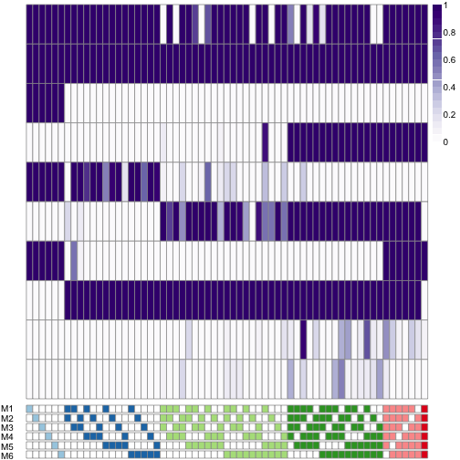

```r
## Extract the functionality, polyfunctionality scores as described within
## the COMPASS paper
FS <- FunctionalityScore(fit)
PFS <- PolyfunctionalityScore(fit)

## Obtain the posterior difference, posterior log ratio from a COMPASSResult
post <- Posterior(fit)

## Plot a heatmap of the mean gammas, to visualize differences in expression
## for each category
plot(fit)
```

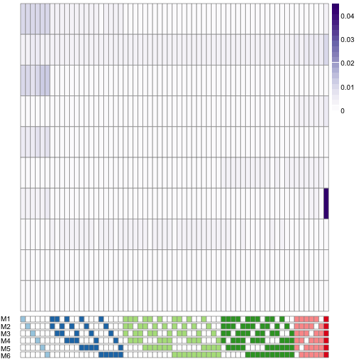

```r
## Visualize the posterior difference, log difference with a heatmap
plot(fit, measure = PosteriorDiff(fit))
```

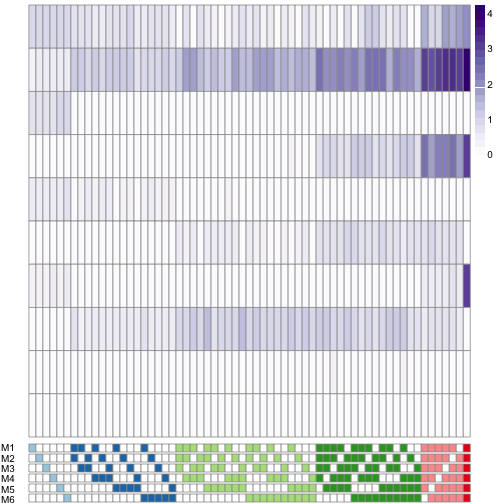

```r
plot(fit, measure = PosteriorLogDiff(fit))
```

`COMPASS` also packages a Shiny application for interactive visualization of the fits generated by a `COMPASS` call. These can be easily generated through a call to the `shinyCOMPASS` function.

```
shinyCOMPASS(fit, stimulated="Treatment", unstimulated="Control")
```

## Interoperation with flowWorkspace

`flowWorkspace` is a package used for managing and generating gates for data obtained from flow cytometry experiments. Combined with `openCyto`, users are able to automatically gate data through flexibly-defined gating templates.

`COMPASS` comes with a utility function for extracting data from a `flowWorkspace` `GatingSet` object, providing a seamless workflow between both data management and analysis for polyfunctionality cytokine data. Data can be extracted using `COMPASSContainerFromGatingSet`, with appropriate documentation available in `?COMPASSContainerFromGatingSet`.

Users who have gated their data with `flowJo` and are interested in analyzing their data with `COMPASS` can do so by first loading and parsing their workspace with `flowWorkspace`, and next generating the `COMPASSContainer` through `COMPASSContainerFromGatingSet`.

## Citations

Greg Finak and Mike Jiang (2011). flowWorkspace: Import flowJo Workspaces into BioConductor and replicate flowJo gating with flowCore. R package version 3.9.37.

Lynn Lin (2013). COMPASS: Combinatorial Polyfunctionality Analysis of Single Cells. R package version 0.92.

Greg Finak, Andrew McDavid, Pratip Chattopadhyay, Maria Dominguez, Steve De Rosa, Mario Roederer, Raphael Gottardo. Mixture models for single-cell assays with applications to vaccine studies. Biostatistics 2014 Jan;15(1):87-101

Mike Jiang, John Ramey, Greg Finak and Raphael Gottardo (2012). openCyto: Hierarchical Gating Pipeline for flow cytometry data. R package version 1.1.3.

R Core Team (2013). R: A language and environment for statistical computing. R Foundation for Statistical Computing, Vienna, Austria. URL http://www.R-project.org/.